# PM566 Assinment03

Author

Wenjia Lu

### Set packages

```r
library(data.table)
library(dplyr)
library(tidyverse)
library(dtplyr)
library(knitr)
library(ggplot2)
library(rvest)
library(httr)
library(xml2)
library(stringr)
library(tidytext)
library(dplyr)
```

## Q1. Tokenize the abstracts and count the number of each token. Do you see anything interesting? Does removing stop words change what tokens appear as the most frequent? What are the 5 most common tokens for each search term after removing stopwords?

```r
if (!file.exists("abstracts.csv")) {
  download.file(
    url = "https://raw.githubusercontent.com/USCbiostats/data-science-data/master/03_pubmed/pubmed.csv", "abstracts.csv", method = "libcurl", timeout  = 60)
}
abs= read.csv("abstracts.csv")

str(abs)
```

```
'data.frame':   3241 obs. of  2 variables:
 $ abstract: chr  "Background and aims: Many patients with coronavirus disease 2019 (COVID-19) have underlying cardiovascular (CV)"| __truncated__ "Introduction: Contradictory data have been reported on the incidence of stroke in patients with COVID-19 and th"| __truncated__ "This article aims at co…
 $ term    : chr  "covid" "covid" "covid" "covid" ...
```

```r
table(abs$term)
```

```
          covid cystic fibrosis      meningitis    preeclampsia prostate cancer
            981             376             317             780             787
```

```r
abs= as_tibble(abs)
```

** The dataset contains 3241 abstracts from articles across 5 search terms.

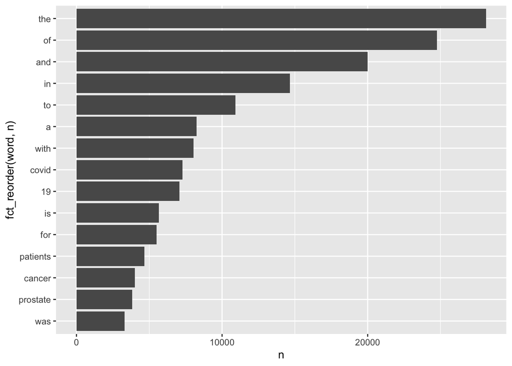

```r
abs %>%
  unnest_tokens(word, abstract) %>%
  count(word, sort = TRUE) %>%
  top_n(15, n) %>%
  ggplot(aes(n, fct_reorder(word, n))) +
  geom_col()
```

** For the top 15 common tokens, only “covid”, “19”, “patients”, “cancer”, and “prostate” are meaningful. Others are stop words and do not convey any interesting information.

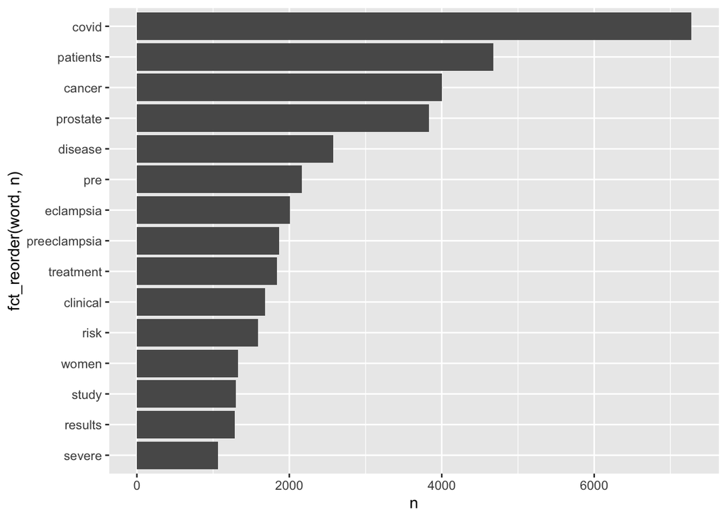

```r
abs %>%
  unnest_tokens(word, abstract) %>%
  anti_join(stop_words, by = c("word")) %>%
  count(word, sort = TRUE) %>%
  filter( !grepl(pattern = "^[0-9]+$", x = word)) %>%
  top_n(15, n) %>%
  ggplot(aes(n, fct_reorder(word, n))) +
  geom_col()
```

```r
abs %>%
  unnest_tokens(word, abstract) %>%
  group_by(term) %>%
  count(word, sort = TRUE) %>%
  filter( !(word %in% stop_words$word) & !grepl(pattern = "^[0-9]+$", x = word)) %>%
  top_n(5, n) %>%
  arrange(term, desc(n)) %>%
knitr::kable()
```

| term | word | n |
| --- | --- | --- |
| covid | covid | 7275 |
| covid | patients | 2293 |
| covid | disease | 943 |
| covid | pandemic | 800 |
| covid | coronavirus | 647 |
| covid | health | 647 |
| cystic fibrosis | fibrosis | 867 |
| cystic fibrosis | cystic | 862 |
| cystic fibrosis | cf | 625 |
| cystic fibrosis | patients | 586 |
| cystic fibrosis | disease | 400 |
| meningitis | patients | 446 |
| meningitis | meningitis | 429 |
| meningitis | meningeal | 219 |
| meningitis | csf | 206 |
| meningitis | clinical | 187 |
| preeclampsia | pre | 2038 |
| preeclampsia | eclampsia | 2005 |
| preeclampsia | preeclampsia | 1863 |
| preeclampsia | women | 1196 |
| preeclampsia | pregnancy | 969 |
| prostate cancer | cancer | 3840 |
| prostate cancer | prostate | 3832 |
| prostate cancer | patients | 934 |
| prostate cancer | treatment | 926 |
| prostate cancer | disease | 652 |

** After removing stopwords, the 5 most common tokens for each term are:

1. covid: covid, patients, disease, pandemic, coronavirus / health (both appeared 647 times)
2. cystic fibrosis: fibrosis, cystic, cf, patients, disease
3. meningitis: patients, meningitis, meningeal, csf, clinical
4. preeclampsia: pre, eclampsia, preeclampsia, women, pregnancy
5. prostate cancer: cancer, prostate, patients, treatment, disease

## Q2. Tokenize the abstracts into bigrams. Find the 10 most common bigram and visualize them with ggplot2.

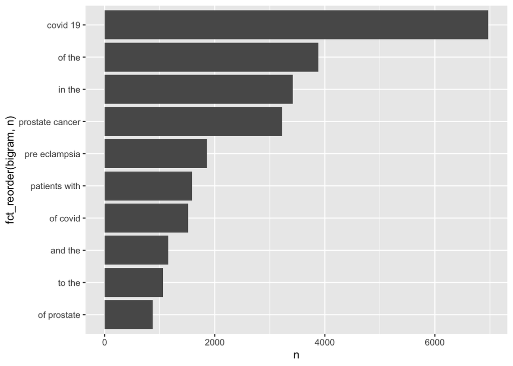

```r
abs %>%
  unnest_ngrams(bigram, abstract, n=2) %>%
  count(bigram, sort = TRUE) %>%
  top_n(10, n) %>%
  ggplot(aes(n, fct_reorder(bigram, n))) +
  geom_col()
```

** Here we can observe that most common bigrams were about COVID-19, Prostate cancer, and Preeclampsia.

## Q3. Calculate the TF-IDF value for each word-search term combination (here you want the search term to be the “document”). What are the 5 tokens from each search term with the highest TF-IDF value? How are the results different from the answers you got in question 1?

```r
abs %>%
  unnest_tokens(word, abstract) %>%
  group_by(term) %>%
  count(word, term, sort = TRUE) %>%
  top_n(5, n) %>%
  bind_tf_idf(word, term, n) %>%
  arrange(term, desc(tf_idf)) %>%
knitr::kable()
```

| term | word | n | tf | idf | tf_idf |
| --- | --- | --- | --- | --- | --- |
| covid | covid | 7275 | 0.1885692 | 1.6094379 | 0.3034904 |
| covid | 19 | 7035 | 0.1823484 | 1.6094379 | 0.2934784 |
| covid | the | 9741 | 0.2524883 | 0.0000000 | 0.0000000 |
| covid | of | 7668 | 0.1987558 | 0.0000000 | 0.0000000 |
| covid | and | 6861 | 0.1778383 | 0.0000000 | 0.0000000 |
| cystic fibrosis | to | 1011 | 0.1091086 | 0.9162907 | 0.0999752 |
| cystic fibrosis | in | 1497 | 0.1615584 | 0.5108256 | 0.0825282 |
| cystic fibrosis | the | 2677 | 0.2889057 | 0.0000000 | 0.0000000 |
| cystic fibrosis | of | 2304 | 0.2486510 | 0.0000000 | 0.0000000 |
| cystic fibrosis | and | 1777 | 0.1917764 | 0.0000000 | 0.0000000 |
| meningitis | a | 830 | 0.0965902 | 1.6094379 | 0.1554560 |
| meningitis | in | 1322 | 0.1538462 | 0.5108256 | 0.0785886 |
| meningitis | the | 2489 | 0.2896544 | 0.0000000 | 0.0000000 |
| meningitis | of | 2269 | 0.2640521 | 0.0000000 | 0.0000000 |
| meningitis | and | 1683 | 0.1958571 | 0.0000000 | 0.0000000 |
| preeclampsia | to | 2651 | 0.1030275 | 0.9162907 | 0.0944031 |
| preeclampsia | in | 3869 | 0.1503634 | 0.5108256 | 0.0768095 |
| preeclampsia | the | 7119 | 0.2766702 | 0.0000000 | 0.0000000 |
| preeclampsia | of | 6837 | 0.2657106 | 0.0000000 | 0.0000000 |
| preeclampsia | and | 5255 | 0.2042284 | 0.0000000 | 0.0000000 |
| prostate cancer | cancer | 3840 | 0.1608646 | 1.6094379 | 0.2589017 |
| prostate cancer | prostate | 3832 | 0.1605295 | 1.6094379 | 0.2583623 |
| prostate cancer | the | 6100 | 0.2555402 | 0.0000000 | 0.0000000 |
| prostate cancer | of | 5682 | 0.2380294 | 0.0000000 | 0.0000000 |
| prostate cancer | and | 4417 | 0.1850362 | 0.0000000 | 0.0000000 |

** There were lots of meaningless and redundant stop words in the table, so better get rid of them.

```r
abs %>%
  unnest_tokens(word, abstract) %>%
  group_by(term) %>%
  count(word, term, sort = TRUE) %>%
  filter( !(word %in% stop_words$word) & !grepl(pattern = "^[0-9]+$", x = word)) %>%
  top_n(5, n) %>%
  bind_tf_idf(word, term, n) %>%
  arrange(term, desc(tf_idf)) %>%
knitr::kable()
```

| term | word | n | tf | idf | tf_idf |
| --- | --- | --- | --- | --- | --- |
| covid | covid | 7275 | 0.5771519 | 1.6094379 | 0.9288902 |
| covid | pandemic | 800 | 0.0634669 | 1.6094379 | 0.1021460 |
| covid | coronavirus | 647 | 0.0513288 | 1.6094379 | 0.0826106 |
| covid | health | 647 | 0.0513288 | 1.6094379 | 0.0826106 |
| covid | patients | 2293 | 0.1819119 | 0.2231436 | 0.0405925 |
| covid | disease | 943 | 0.0748116 | 0.5108256 | 0.0382157 |
| cystic fibrosis | fibrosis | 867 | 0.2595808 | 1.6094379 | 0.4177792 |
| cystic fibrosis | cystic | 862 | 0.2580838 | 1.6094379 | 0.4153699 |
| cystic fibrosis | cf | 625 | 0.1871257 | 1.6094379 | 0.3011673 |
| cystic fibrosis | disease | 400 | 0.1197605 | 0.5108256 | 0.0611767 |
| cystic fibrosis | patients | 586 | 0.1754491 | 0.2231436 | 0.0391503 |
| meningitis | meningitis | 429 | 0.2885003 | 1.6094379 | 0.4643234 |
| meningitis | meningeal | 219 | 0.1472764 | 1.6094379 | 0.2370322 |
| meningitis | csf | 206 | 0.1385340 | 1.6094379 | 0.2229618 |
| meningitis | clinical | 187 | 0.1257566 | 1.6094379 | 0.2023974 |
| meningitis | patients | 446 | 0.2999328 | 0.2231436 | 0.0669281 |
| preeclampsia | pre | 2038 | 0.2525090 | 1.6094379 | 0.4063975 |
| preeclampsia | eclampsia | 2005 | 0.2484203 | 1.6094379 | 0.3998170 |
| preeclampsia | preeclampsia | 1863 | 0.2308264 | 1.6094379 | 0.3715008 |
| preeclampsia | women | 1196 | 0.1481849 | 1.6094379 | 0.2384943 |
| preeclampsia | pregnancy | 969 | 0.1200595 | 1.6094379 | 0.1932283 |
| prostate cancer | cancer | 3840 | 0.3770621 | 1.6094379 | 0.6068580 |
| prostate cancer | prostate | 3832 | 0.3762765 | 1.6094379 | 0.6055937 |
| prostate cancer | treatment | 926 | 0.0909269 | 1.6094379 | 0.1463413 |
| prostate cancer | disease | 652 | 0.0640220 | 0.5108256 | 0.0327041 |
| prostate cancer | patients | 934 | 0.0917125 | 0.2231436 | 0.0204651 |

1. covid: covid, pandemic, coronavirus / health (both TF-IDF values equal 0.0826106), patients, disease
2. cystic fibrosis: fibrosis, cystic, cf, disease, patients
3. meningitis: meningitis, meningeal, csf, clinial, patients
4. preeclampsia: pre, eclampsia, preeclampsia, women, pregnancy
5. prostate cancer: cancer，prostate, treatment, disease, patients